# Deaths - EPI1 Scenarios

Pragati Prasad

2021-04-27

## Mean, Cumulative with 95% CI, and Averted per 100K

### Scenario HP01

Base Scenario: R0 1.4 and “2009-like” severity

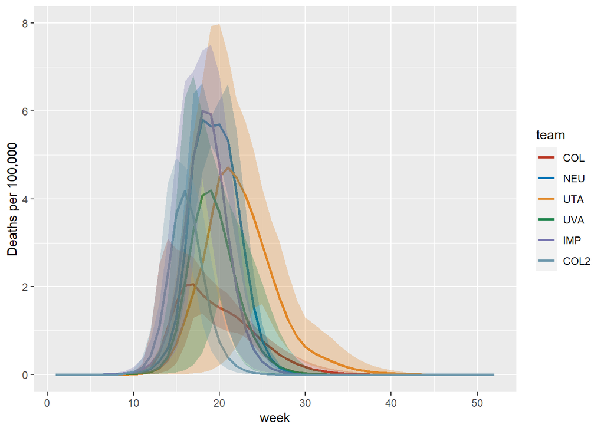

```r
library(ggsci)
library(reshape)
library(dplyr)
library(gridExtra)
library(ggplot2)
library(egg)
library(plyr)
library(tidyr)
library(knitr)
library(kableExtra)

path <- "../model-forecasts/"

team.folder <- c("Columbia/COL/EPI1/", "Northeastern/EPI1/", "UTAustin/", "UVirginia/", "Imperial/", "Columbia/COL2/EPI1/")
team.abbrev <- c("COL", "NEU", "UTA", "UVA", "IMP", "COL2")
file.types <-c("SymIllness", "Hosp", "Deaths", "AntiviralTX")
scn = "HP01_"
read_overall_mean <- function(scn){

  cols <- c("sm.mean", "sm.perc2p5", "sm.perc97p5")

  s <- read.csv(paste0(path,team.folder[1],scn,file.types[3],"_",team.abbrev[1],".csv"))
  death <- data.frame(c(s[which(s$Agegroup == "Overall" &
                                       s$Bin %in% cols),],
                             `team` = team.abbrev[1]))

  for(i in 2:6){

    if(i == 4){
      scn = gsub("HP", "HP_", scn)
    }
    if(i == 5){
      scn = gsub("_", "", scn)
    }
    if(i == 6){
      scn = paste0(scn, "_")
    }
    f = paste0(path,team.folder[i],scn,file.types[3],"_",team.abbrev[i],".csv")
    if(i == 5){
      f =  paste0(path,team.folder[i],scn,"Death",team.abbrev[i],".csv")
    }

    if(file.exists(f)){
      s <- read.csv(f)
      if(ncol(s) > 59){
        s <- s[-1]
      }
      if(i == 4){
        s <- s[which(s$Location == "US National"),]
      }
      death <- rbind.fill(death,
                               data.frame(c(s[which(s$Agegroup == "Overall" &
                                                      s$Bin %in% cols),],`team` = team.abbrev[i])))
    }

  }
  weeks <- paste0("Week",1:52)
  death$Cml[which(is.na(death$Cml))] <- death$cml[which(is.na(death$Cml))]
  cml <<- death[c("Cml", "team", "Bin")]

  long <- gather(death, week, illnesses, weeks, factor_key=TRUE)
  long$week <- as.integer(gsub("Week", "", long$week))

  cols <- c("Bin", "team", "week", "illnesses")
  long <- long[cols]
  long_wide <- spread(long, Bin, illnesses)

  return(long_wide)
}

long_HP01 <- read_overall_mean(scn = "HP01_")

ggplot(data = long_HP01, aes(x = week, y = sm.mean, group = team)) +
  geom_line(aes(color = team), lwd = 1.0) +
  geom_ribbon(aes(ymin = sm.perc2p5, ymax = sm.perc97p5, fill = team), alpha = 0.3,
              show.legend = FALSE)+
  ylab("Deaths per 100,000") +
  scale_color_nejm() +
  scale_fill_nejm()
```

```r
table <- cml[which(cml$Bin == "sm.mean"),]
table <- table[,-3]

table$lower <-  cml$Cml[which(cml$Bin == "sm.perc2p5")]
table$upper <-  cml$Cml[which(cml$Bin == "sm.perc97p5")]
table$Team <- table$team
table$`Cum. Deaths per 100K` <- table$Cml
table$`95% CI` <- paste0("(", round(table$lower, 2), ", ", round(table$upper, 2), ")")

rownames(table) <- NULL

knitr::kable(table[5:7], digits = 2, caption = "HP01, No Intervention", align=rep('c', 3)) %>%
  kable_styling(bootstrap_options = c("striped", "hover"))
```

HP01, No Intervention

| Team | Cum. Deaths per 100K | 95% CI |
| --- | --- | --- |
| COL | 20.29 | (14.86, 26.76) |
| NEU | 42.56 | (42.37, 43.15) |
| UTA | 43.57 | (21.05, 59.67) |
| UVA | 27.56 | (21.42, 32.98) |
| IMP | 36.28 | (33.3, 41.04) |
| COL2 | 20.78 | (19.46, 22.06) |

```r
table1 <- table
team.folder <- c("Columbia/COL/EPI1/", "Northeastern/EPI1/", "UTAustin/", "UVirginia/Old_UVA/", "Imperial/", "Columbia/COL2/EPI1/")

## Bar charts for age stratification
read_ages <- function(scn){

  cols <- c("sm.mean", "sm.perc2p5", "sm.perc97p5")

  s <- read.csv(paste0(path,team.folder[1],scn,file.types[3],"_",team.abbrev[1],".csv"))
  death <- data.frame(c(s[which(s$Bin %in% cols),],
                        `team` = team.abbrev[1]))

  for(i in 2:6){

    if(i == 4){
      scn = gsub("HP", "HP_", scn)
    }
    if(i == 5){
      scn = gsub("_", "", scn)
    }
    if(i == 6){
      scn = paste0(scn, "_")
    }
    f = paste0(path,team.folder[i],scn,file.types[3],"_",team.abbrev[i],".csv")
    if(i == 5){
      f =  paste0(path,team.folder[i],scn,"Death",team.abbrev[i],".csv")
    }

    if(file.exists(f)){
      s <- read.csv(f)
      if(ncol(s) > 59){
        s <- s[-1]
      }
      if(i == 4){
        s <- s[which(s$Location == "US National"),]
      }
      death <- rbind.fill(death,
                               data.frame(c(s[which(s$Bin %in% cols),],`team` = team.abbrev[i])))
    }

  }
  weeks <- paste0("Week",1:52)
  death$Cml[which(is.na(death$Cml))] <- death$cml[which(is.na(death$Cml))]
  cml <- death[c("Cml", "team", "Bin", "Agegroup")]
  cml$Agegroup <- sub("yr", "years", cml$Agegroup)
  cml$Agegroup <- factor(x = cml$Agegroup, levels = c("Overall", "0-4 years", "5-17 years", "18-49 years", "50-64 years", "65+ years"))

  return(cml)
}

ages_1 <- read_ages(scn = "HP01_")
png("age_supp1b.png",width = 850, height=500)
ggplot(ages_1[which(ages_1$Agegroup != "Overall"),], aes(fill=Agegroup, y=Cml, x=team)) +
  geom_bar(position="fill", stat="identity") +
  ylab("Percent")+
  scale_fill_d3()
dev.off()
```

```r
scenario="HP01_"
averted_age <- data.frame(scenario = scenario,
                          team = ages_1$team[which(ages_1$Bin == "sm.mean")],
                          agegroup = ages_1$Agegroup[which(ages_1$Bin == "sm.mean")],
                          cml = ages_1$Cml[which(ages_1$Bin == "sm.mean")],
                          lower = ages_1$Cml[which(ages_1$Bin == "sm.perc2p5")],
                          upper = ages_1$Cml[which(ages_1$Bin == "sm.perc97p5")])
write.csv(averted_age, "Deaths_EPI1_HP01.csv")
```

### HP02

VX1

“Early”: Vaccine available 100 days after September 1

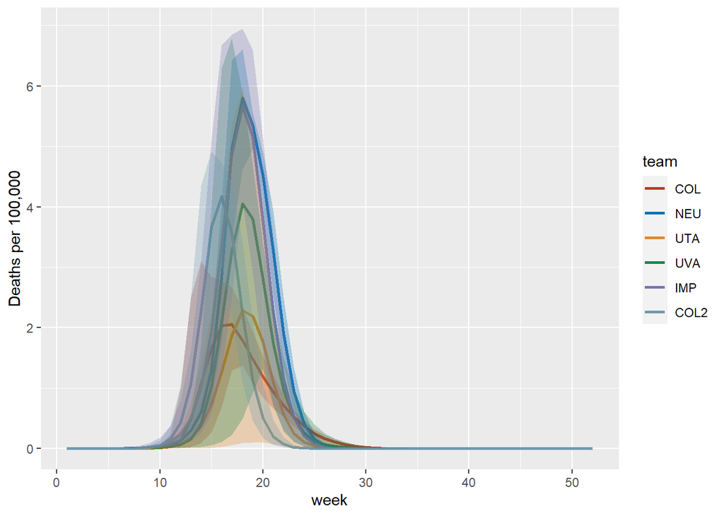

```r
scenario <- "HP02_"

long <- read_overall_mean(scn = scenario)

ggplot(data = long, aes(x = week, y = sm.mean, group = team)) +
  geom_line(aes(color = team), lwd = 1.0) +
  geom_ribbon(aes(ymin = sm.perc2p5, ymax = sm.perc97p5, fill = team), alpha = 0.3,
              show.legend = FALSE)+
  ylab("Deaths per 100,000") +
  scale_color_nejm() +
  scale_fill_nejm()
```

```r
table <- cml[which(cml$Bin == "sm.mean"),]
table <- table[,-3]

table$lower <-  cml$Cml[which(cml$Bin == "sm.perc2p5")]
table$upper <-  cml$Cml[which(cml$Bin == "sm.perc97p5")]
table$Team <- table$team
table$`Cum. Deaths per 100K` <- table$Cml
table$`95% CI` <- paste0("(", round(table$lower, 2), ", ", round(table$upper, 2), ")")

table$`Averted Deaths per 100K (HP01)` <- ifelse(table$Team %in% table1$Team, table1$`Cum. Deaths per 100K` - table$`Cum. Deaths per 100K`, NA)
table$`% Reduction in Burden (HP01)` <- ifelse(table$Team %in% table1$Team, 100 * (table1$`Cum. Deaths per 100K` - table$`Cum. Deaths per 100K`) / table1$`Cum. Deaths per 100K`, NA)

rownames(table) <- NULL

knitr::kable(table[5:9], digits = 2, caption = "HP02: Compared to HP01", align=rep('c', 4)) %>%
  kable_styling(bootstrap_options = c("striped", "hover"))
```

HP02: Compared to HP01

| Team | Cum. Deaths per 100K | 95% CI | Averted Deaths per 100K (HP01) | % Reduction in Burden (HP01) |
| --- | --- | --- | --- | --- |
| COL | 15.18 | (9.21, 23.21) | 5.11 | 25.18 |
| NEU | 32.72 | (31.9, 35.09) | 9.84 | 23.13 |
| UTA | 12.84 | (0.59, 33.07) | 30.72 | 70.52 |
| UVA | 21.55 | (8.58, 31.39) | 6.01 | 21.82 |
| IMP | 30.94 | (25.19, 36.27) | 5.33 | 14.71 |
| COL2 | 19.62 | (17.22, 21.37) | 1.16 | 5.57 |

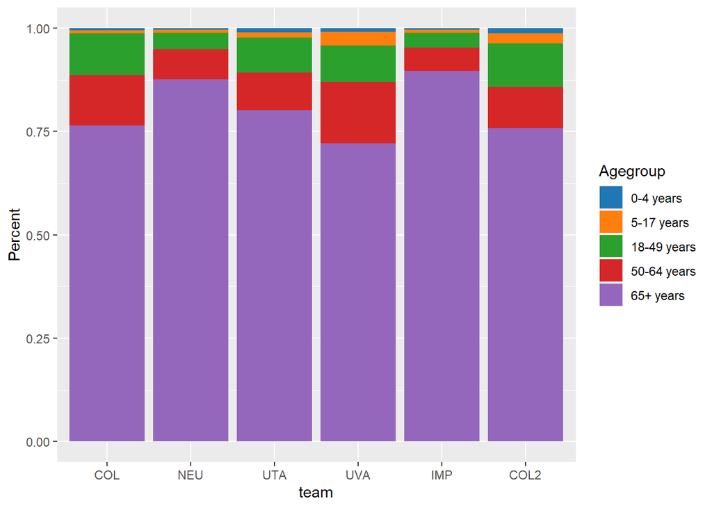

```r
ages <- read_ages(scn = scenario)
ggplot(ages[which(ages$Agegroup != "Overall"),], aes(fill=Agegroup, y=Cml, x=team)) +
  geom_bar(position="fill", stat="identity") +
  ylab("Percent")+
  scale_fill_d3()
```

```r
averted <- data.frame(scenario = rep(scenario, nrow(table)),
                                     team = table$Team,
                                     reduction = table$`% Reduction in Burden (HP01)`)
averted_age <- data.frame(scenario = scenario,
                          team = ages$team[which(ages$Bin == "sm.mean")],
                          agegroup = ages$Agegroup[which(ages$Bin == "sm.mean")],
                          reduction = 100*(ages_1$Cml[which(ages_1$Bin == "sm.mean")] -
                                       ages$Cml[which(ages$Bin == "sm.mean")]) /
                            ages_1$Cml[which(ages_1$Bin == "sm.mean")])
```

### HP03

VX2

“Normal”: Vaccine available 150 days after September 1

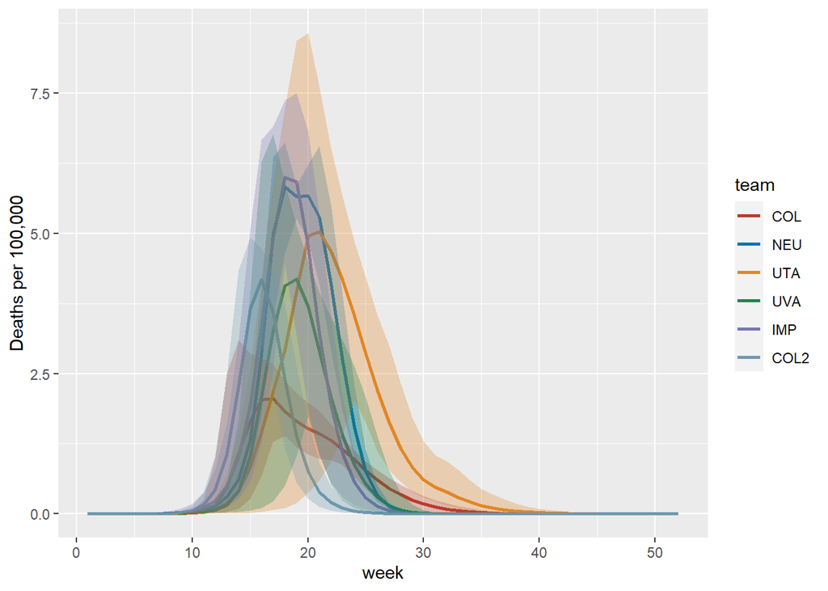

```r
scenario <- "HP03_"

long <- read_overall_mean(scn = scenario)

ggplot(data = long, aes(x = week, y = sm.mean, group = team)) +
  geom_line(aes(color = team), lwd = 1.0) +
  geom_ribbon(aes(ymin = sm.perc2p5, ymax = sm.perc97p5, fill = team), alpha = 0.3,
              show.legend = FALSE)+
  ylab("Deaths per 100,000") +
  scale_color_nejm() +
  scale_fill_nejm()
```

```r
table <- cml[which(cml$Bin == "sm.mean"),]
table <- table[,-3]

table$lower <-  cml$Cml[which(cml$Bin == "sm.perc2p5")]
table$upper <-  cml$Cml[which(cml$Bin == "sm.perc97p5")]
table$Team <- table$team
table$`Cum. Deaths per 100K` <- table$Cml
table$`95% CI` <- paste0("(", round(table$lower, 2), ", ", round(table$upper, 2), ")")

table$`Averted Deaths per 100K (HP01)` <- ifelse(table$Team %in% table1$Team, table1$`Cum. Deaths per 100K` - table$`Cum. Deaths per 100K`, NA)
table$`% Reduction in Burden (HP01)` <- ifelse(table$Team %in% table1$Team, 100 * (table1$`Cum. Deaths per 100K` - table$`Cum. Deaths per 100K`) / table1$`Cum. Deaths per 100K`, NA)

rownames(table) <- NULL

knitr::kable(table[5:9], digits = 2, caption = "HP03: Compared to HP01", align=rep('c', 4)) %>%
  kable_styling(bootstrap_options = c("striped", "hover"))
```

HP03: Compared to HP01

| Team | Cum. Deaths per 100K | 95% CI | Averted Deaths per 100K (HP01) | % Reduction in Burden (HP01) |
| --- | --- | --- | --- | --- |
| COL | 20.29 | (14.86, 26.76) | 0.00 | 0.00 |
| NEU | 42.48 | (42.3, 43.04) | 0.08 | 0.19 |
| UTA | 45.61 | (23.06, 61.69) | -2.04 | -4.68 |
| UVA | 27.39 | (20.32, 32.98) | 0.17 | 0.61 |
| IMP | 36.21 | (33.19, 40.97) | 0.07 | 0.19 |
| COL2 | 20.77 | (19.44, 22.05) | 0.01 | 0.04 |

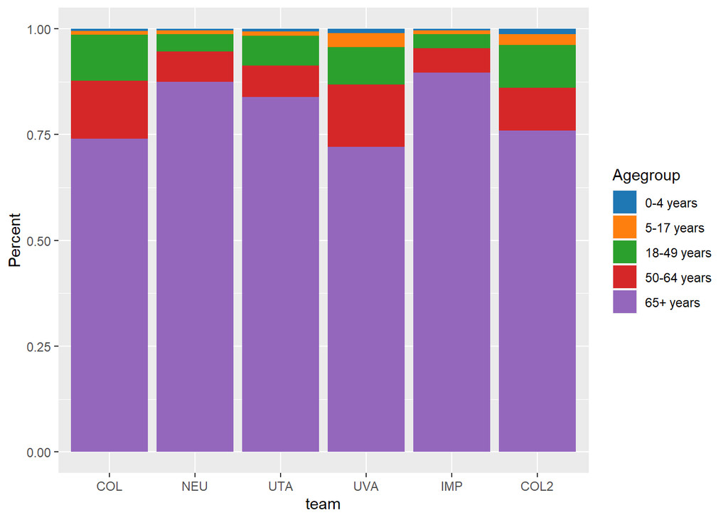

```r
ages <- read_ages(scn = scenario)
ggplot(ages[which(ages$Agegroup != "Overall"),],aes(fill=Agegroup, y=Cml, x=team)) +
  geom_bar(position="fill", stat="identity") +
  ylab("Percent")+
  scale_fill_d3()
```

```r
averted <- rbind(averted, data.frame(scenario = rep(scenario, nrow(table)),
                                     team = table$Team,
                                     reduction = table$`% Reduction in Burden (HP01)`))
averted_age <- rbind(averted_age,
                     data.frame(scenario = scenario,
                          team = ages$team[which(ages$Bin == "sm.mean")],
                          agegroup = ages$Agegroup[which(ages$Bin == "sm.mean")],
                          reduction = 100*(ages_1$Cml[which(ages_1$Bin == "sm.mean")] -
                                       ages$Cml[which(ages$Bin == "sm.mean")]) /
                            ages_1$Cml[which(ages_1$Bin == "sm.mean")]))
```

### HP04

SC1

Weekly Symptomatic Prevalence > 1% trigger, early (VX1) vaccine availability reopening

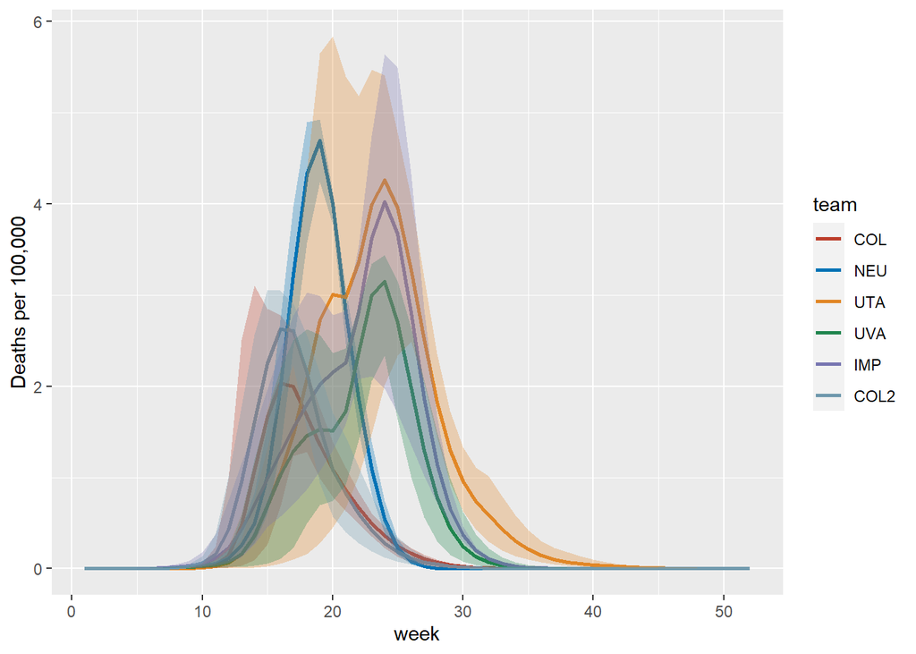

```r
scenario <- "HP04_"

long <- read_overall_mean(scn = scenario)

ggplot(data = long, aes(x = week, y = sm.mean, group = team, color = team)) +
  geom_line(aes(color = team), lwd = 1.0) +
  geom_ribbon(aes(ymin = sm.perc2p5, ymax = sm.perc97p5, fill = team),
              alpha = 0.3,
              linetype=0,
              show.legend = FALSE)+
  ylab("Deaths per 100,000") +
  scale_color_nejm() +
  scale_fill_nejm()
```

```r
table <- cml[which(cml$Bin == "sm.mean"),]
table <- table[,-3]

table$lower <-  cml$Cml[which(cml$Bin == "sm.perc2p5")]
table$upper <-  cml$Cml[which(cml$Bin == "sm.perc97p5")]
table$Team <- table$team
table$`Cum. Deaths per 100K` <- table$Cml
table$`95% CI` <- paste0("(", round(table$lower, 2), ", ", round(table$upper, 2), ")")

table$`Averted Deaths per 100K (HP01)` <- ifelse(table$Team %in% table1$Team, table1$`Cum. Deaths per 100K` - table$`Cum. Deaths per 100K`, NA)
table$`% Reduction in Burden (HP01)` <- ifelse(table$Team %in% table1$Team, 100 * (table1$`Cum. Deaths per 100K` - table$`Cum. Deaths per 100K`) / table1$`Cum. Deaths per 100K`, NA)

rownames(table) <- NULL

knitr::kable(table[5:9], digits = 2, caption = "HP04: Compared to HP01", align=rep('c', 4)) %>%
  kable_styling(bootstrap_options = c("striped", "hover"))
```

HP04: Compared to HP01

| Team | Cum. Deaths per 100K | 95% CI | Averted Deaths per 100K (HP01) | % Reduction in Burden (HP01) |
| --- | --- | --- | --- | --- |
| COL | 14.63 | (8.81, 22.57) | 5.66 | 27.91 |
| NEU | 26.91 | (26.22, 28.83) | 15.66 | 36.79 |
| UTA | 42.87 | (21.3, 57.88) | 0.70 | 1.60 |
| UVA | 26.17 | (20.99, 30.41) | 1.39 | 5.06 |
| IMP | 35.04 | (32.08, 40.34) | 1.24 | 3.41 |
| COL2 | 18.14 | (16.92, 19.35) | 2.65 | 12.73 |

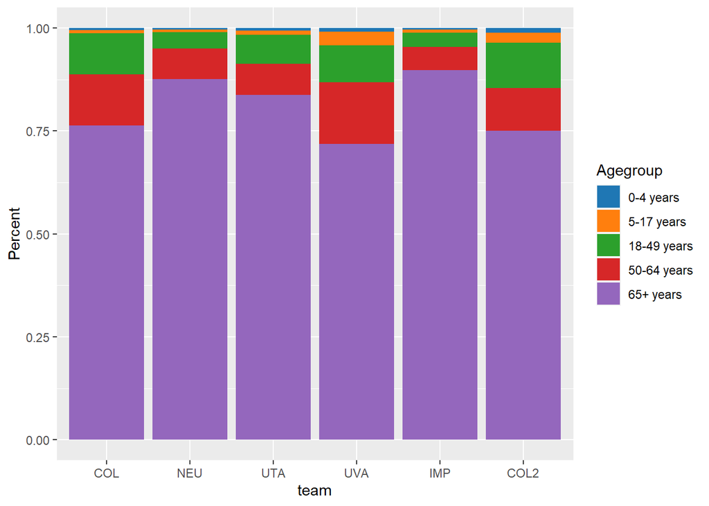

```r
ages <- read_ages(scn = scenario)
ggplot(ages[which(ages$Agegroup != "Overall"),],aes(fill=Agegroup, y=Cml, x=team)) +
  geom_bar(position="fill", stat="identity") +
  ylab("Percent")+
  scale_fill_d3()
```

```r
averted <- rbind(averted, data.frame(scenario = rep(scenario, nrow(table)),
                                     team = table$Team,
                                     reduction = table$`% Reduction in Burden (HP01)`))
averted_age <- rbind(averted_age,
                     data.frame(scenario = scenario,
                          team = ages$team[which(ages$Bin == "sm.mean")],
                          agegroup = ages$Agegroup[which(ages$Bin == "sm.mean")],
                          reduction = 100*(ages_1$Cml[which(ages_1$Bin == "sm.mean")] -
                                       ages$Cml[which(ages$Bin == "sm.mean")]) /
                            ages_1$Cml[which(ages_1$Bin == "sm.mean")]))
```

### HP05

SC2

Close on October 28, early (VX1) vaccine availability reopening

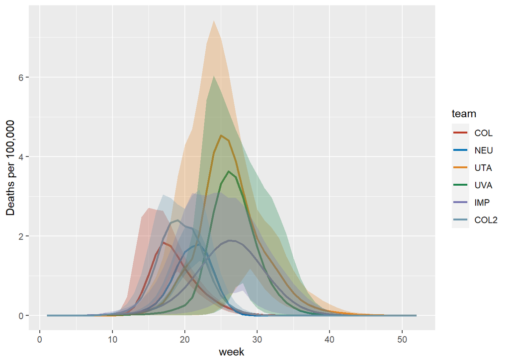

```r
scenario <- "HP05_"

long <- read_overall_mean(scn = scenario)

ggplot(data = long, aes(x = week, y = sm.mean, group = team)) +
  geom_line(aes(color = team), lwd = 1.0) +
  geom_ribbon(aes(ymin = sm.perc2p5, ymax = sm.perc97p5, fill = team), alpha = 0.3,
              show.legend = FALSE)+
  ylab("Deaths per 100,000") +
  scale_color_nejm() +
  scale_fill_nejm()
```

```r
table <- cml[which(cml$Bin == "sm.mean"),]
table <- table[,-3]

table$lower <-  cml$Cml[which(cml$Bin == "sm.perc2p5")]
table$upper <-  cml$Cml[which(cml$Bin == "sm.perc97p5")]
table$Team <- table$team
table$`Cum. Deaths per 100K` <- table$Cml
table$`95% CI` <- paste0("(", round(table$lower, 2), ", ", round(table$upper, 2), ")")

table$`Averted Deaths per 100K (HP01)` <- ifelse(table$Team %in% table1$Team, table1$`Cum. Deaths per 100K` - table$`Cum. Deaths per 100K`, NA)
table$`% Reduction in Burden (HP01)` <- ifelse(table$Team %in% table1$Team, 100 * (table1$`Cum. Deaths per 100K` - table$`Cum. Deaths per 100K`) / table1$`Cum. Deaths per 100K`, NA)

rownames(table) <- NULL

knitr::kable(table[5:9], digits = 2, caption = "HP05: Compared to HP01", align=rep('c', 4)) %>%
  kable_styling(bootstrap_options = c("striped", "hover"))
```

HP05: Compared to HP01

| Team | Cum. Deaths per 100K | 95% CI | Averted Deaths per 100K (HP01) | % Reduction in Burden (HP01) |
| --- | --- | --- | --- | --- |
| COL | 13.10 | (7.29, 20.73) | 7.19 | 35.42 |
| NEU | 12.37 | (11.2, 15.67) | 30.19 | 70.93 |
| UTA | 41.38 | (15.25, 59.6) | 2.18 | 5.01 |
| UVA | 27.43 | (21.39, 32.54) | 0.13 | 0.49 |
| IMP | 22.14 | (13.03, 28.99) | 14.14 | 38.98 |
| COL2 | 19.31 | (18.13, 20.54) | 1.47 | 7.07 |

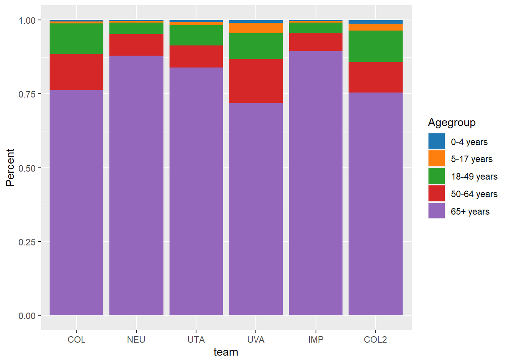

```r
ages <- read_ages(scn = scenario)
ggplot(ages[which(ages$Agegroup != "Overall"),],aes(fill=Agegroup, y=Cml, x=team)) +
  geom_bar(position="fill", stat="identity") +
  ylab("Percent")+
  scale_fill_d3()
```

```r
averted <- rbind(averted, data.frame(scenario = rep(scenario, nrow(table)),
                                     team = table$Team,
                                     reduction = table$`% Reduction in Burden (HP01)`))
averted_age <- rbind(averted_age,
                     data.frame(scenario = scenario,
                          team = ages$team[which(ages$Bin == "sm.mean")],
                          agegroup = ages$Agegroup[which(ages$Bin == "sm.mean")],
                          reduction = 100*(ages_1$Cml[which(ages_1$Bin == "sm.mean")] -
                                       ages$Cml[which(ages$Bin == "sm.mean")]) /
                            ages_1$Cml[which(ages_1$Bin == "sm.mean")]))
```

### HP06

SC3

Weekly Symptomatic Prevalence > 1% trigger, normal (VX2) vaccine availability reopening

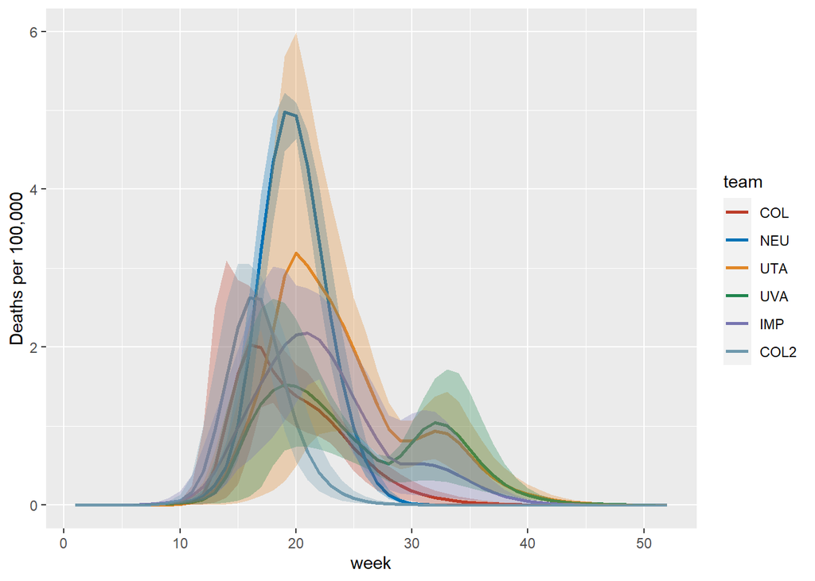

```r
scenario <- "HP06_"

long <- read_overall_mean(scn = scenario)

ggplot(data = long, aes(x = week, y = sm.mean, group = team)) +
  geom_line(aes(color = team), lwd = 1.0) +
  geom_ribbon(aes(ymin = sm.perc2p5, ymax = sm.perc97p5, fill = team), alpha = 0.3,
              show.legend = FALSE)+
  ylab("Deaths per 100,000") +
  scale_color_nejm() +
  scale_fill_nejm()
```

```r
table <- cml[which(cml$Bin == "sm.mean"),]
table <- table[,-3]

table$lower <-  cml$Cml[which(cml$Bin == "sm.perc2p5")]
table$upper <-  cml$Cml[which(cml$Bin == "sm.perc97p5")]
table$Team <- table$team
table$`Cum. Deaths per 100K` <- table$Cml
table$`95% CI` <- paste0("(", round(table$lower, 2), ", ", round(table$upper, 2), ")")

table$`Averted Deaths per 100K (HP01)` <- ifelse(table$Team %in% table1$Team, table1$`Cum. Deaths per 100K` - table$`Cum. Deaths per 100K`, NA)
table$`% Reduction in Burden (HP01)` <- ifelse(table$Team %in% table1$Team, 100 * (table1$`Cum. Deaths per 100K` - table$`Cum. Deaths per 100K`) / table1$`Cum. Deaths per 100K`, NA)

rownames(table) <- NULL

knitr::kable(table[5:9], digits = 2, caption = "HP06: Compared to HP01", align=rep('c', 4)) %>%
  kable_styling(bootstrap_options = c("striped", "hover"))
```

HP06: Compared to HP01

| Team | Cum. Deaths per 100K | 95% CI | Averted Deaths per 100K (HP01) | % Reduction in Burden (HP01) |
| --- | --- | --- | --- | --- |
| COL | 19.42 | (13.96, 25.92) | 0.87 | 4.28 |
| NEU | 35.05 | (35.01, 35.17) | 7.52 | 17.66 |
| UTA | 36.48 | (14.35, 52.26) | 7.09 | 16.27 |
| UVA | 23.42 | (19.38, 27) | 4.15 | 15.05 |
| IMP | 27.00 | (24.16, 31.07) | 9.28 | 25.59 |
| COL2 | 17.18 | (15.82, 18.51) | 3.61 | 17.35 |

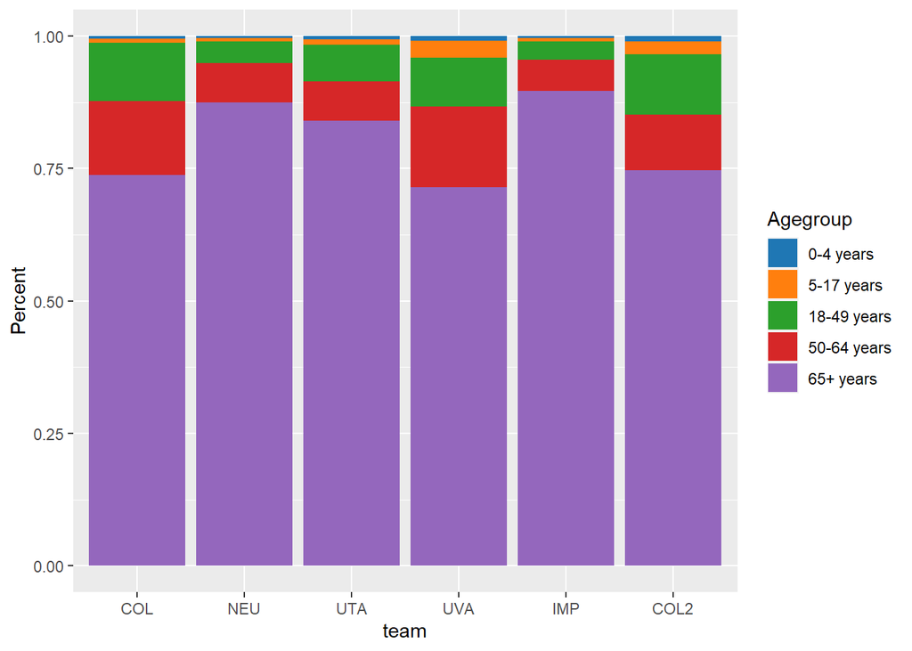

```r
ages <- read_ages(scn = scenario)
ggplot(ages[which(ages$Agegroup != "Overall"),],aes(fill=Agegroup, y=Cml, x=team)) +
  geom_bar(position="fill", stat="identity") +
  ylab("Percent")+
  scale_fill_d3()
```

```r
averted <- rbind(averted, data.frame(scenario = rep(scenario, nrow(table)),
                                     team = table$Team,
                                     reduction = table$`% Reduction in Burden (HP01)`))
averted_age <- rbind(averted_age,
                     data.frame(scenario = scenario,
                          team = ages$team[which(ages$Bin == "sm.mean")],
                          agegroup = ages$Agegroup[which(ages$Bin == "sm.mean")],
                          reduction = 100*(ages_1$Cml[which(ages_1$Bin == "sm.mean")] -
                                       ages$Cml[which(ages$Bin == "sm.mean")]) /
                            ages_1$Cml[which(ages_1$Bin == "sm.mean")]))
```

### HP07

SC4

Close on October 28, normal (VX2) vaccine availability reopening

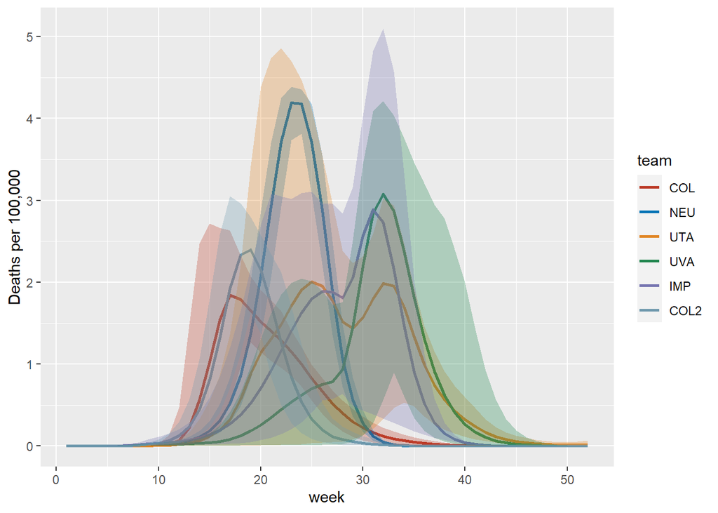

```r
scenario <- "HP07_"

long <- read_overall_mean(scn = scenario)

ggplot(data = long, aes(x = week, y = sm.mean, group = team)) +
  geom_line(aes(color = team), lwd = 1.0) +
  geom_ribbon(aes(ymin = sm.perc2p5, ymax = sm.perc97p5, fill = team), alpha = 0.3,
              show.legend = FALSE)+
  ylab("Deaths per 100,000") +
  scale_color_nejm() +
  scale_fill_nejm()
```

```r
table <- cml[which(cml$Bin == "sm.mean"),]
table <- table[,-3]

table$lower <-  cml$Cml[which(cml$Bin == "sm.perc2p5")]
table$upper <-  cml$Cml[which(cml$Bin == "sm.perc97p5")]
table$Team <- table$team
table$`Cum. Deaths per 100K` <- table$Cml
table$`95% CI` <- paste0("(", round(table$lower, 2), ", ", round(table$upper, 2), ")")

table$`Averted Deaths per 100K (HP01)` <- ifelse(table$Team %in% table1$Team, table1$`Cum. Deaths per 100K` - table$`Cum. Deaths per 100K`, NA)
table$`% Reduction in Burden (HP01)` <- ifelse(table$Team %in% table1$Team, 100 * (table1$`Cum. Deaths per 100K` - table$`Cum. Deaths per 100K`) / table1$`Cum. Deaths per 100K`, NA)

rownames(table) <- NULL

knitr::kable(table[5:9], digits = 2, caption = "HP07: Compared to HP01", align=rep('c', 4)) %>%
  kable_styling(bootstrap_options = c("striped", "hover"))
```

HP07: Compared to HP01

| Team | Cum. Deaths per 100K | 95% CI | Averted Deaths per 100K (HP01) | % Reduction in Burden (HP01) |
| --- | --- | --- | --- | --- |
| COL | 18.61 | (13.22, 24.99) | 1.68 | 8.26 |
| NEU | 31.25 | (30.83, 32.4) | 11.31 | 26.58 |
| UTA | 32.69 | (6.56, 53.7) | 10.87 | 24.96 |
| UVA | 26.61 | (21.35, 29.69) | 0.95 | 3.46 |
| IMP | 30.97 | (27.99, 35.93) | 5.31 | 14.63 |
| COL2 | 17.13 | (15.76, 18.52) | 3.66 | 17.59 |

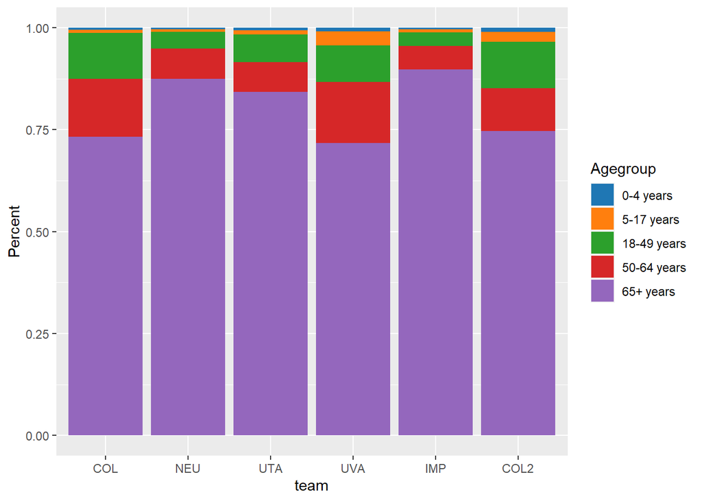

```r
ages <- read_ages(scn = scenario)
ggplot(ages[which(ages$Agegroup != "Overall"),],aes(fill=Agegroup, y=Cml, x=team)) +
  geom_bar(position="fill", stat="identity") +
  ylab("Percent")+
  scale_fill_d3()
```

```r
averted <- rbind(averted, data.frame(scenario = rep(scenario, nrow(table)),
                                     team = table$Team,
                                     reduction = table$`% Reduction in Burden (HP01)`))
averted_age <- rbind(averted_age,
                     data.frame(scenario = scenario,
                          team = ages$team[which(ages$Bin == "sm.mean")],
                          agegroup = ages$Agegroup[which(ages$Bin == "sm.mean")],
                          reduction = 100*(ages_1$Cml[which(ages_1$Bin == "sm.mean")] -
                                       ages$Cml[which(ages$Bin == "sm.mean")]) /
                            ages_1$Cml[which(ages_1$Bin == "sm.mean")]))
```

### HP08

AV

Antivirals

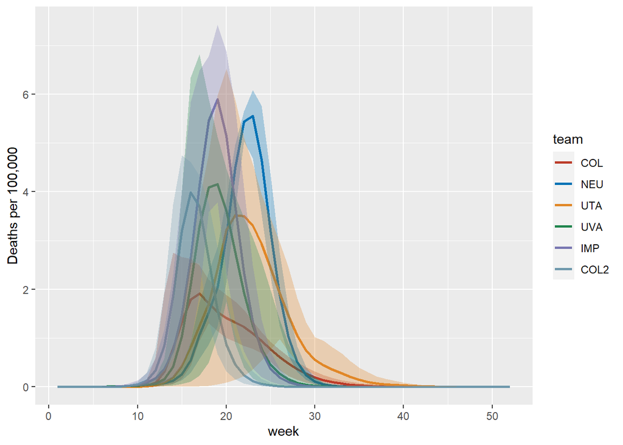

```r
scenario <- "HP08_"

long <- read_overall_mean(scn = scenario)

ggplot(data = long, aes(x = week, y = sm.mean, group = team)) +
  geom_line(aes(color = team), lwd = 1.0) +
  geom_ribbon(aes(ymin = sm.perc2p5, ymax = sm.perc97p5, fill = team), alpha = 0.3,
              show.legend = FALSE)+
  ylab("Deaths per 100,000") +
  scale_color_nejm() +
  scale_fill_nejm()
```

```r
table <- cml[which(cml$Bin == "sm.mean"),]
table <- table[,-3]

table$lower <-  cml$Cml[which(cml$Bin == "sm.perc2p5")]
table$upper <-  cml$Cml[which(cml$Bin == "sm.perc97p5")]
table$Team <- table$team
table$`Cum. Deaths per 100K` <- table$Cml
table$`95% CI` <- paste0("(", round(table$lower, 2), ", ", round(table$upper, 2), ")")

table$`Averted Deaths per 100K (HP01)` <- ifelse(table$Team %in% table1$Team, table1$`Cum. Deaths per 100K` - table$`Cum. Deaths per 100K`, NA)
table$`% Reduction in Burden (HP01)` <- ifelse(table$Team %in% table1$Team, 100 * (table1$`Cum. Deaths per 100K` - table$`Cum. Deaths per 100K`) / table1$`Cum. Deaths per 100K`, NA)

rownames(table) <- NULL

knitr::kable(table[5:9], digits = 2, caption = "HP08: Compared to HP01", align=rep('c', 4)) %>%
  kable_styling(bootstrap_options = c("striped", "hover"))
```

HP08: Compared to HP01

| Team | Cum. Deaths per 100K | 95% CI | Averted Deaths per 100K (HP01) | % Reduction in Burden (HP01) |
| --- | --- | --- | --- | --- |
| COL | 18.61 | (13.25, 24.94) | 1.68 | 8.26 |
| NEU | 36.05 | (35.98, 36.22) | 6.51 | 15.30 |
| UTA | 33.39 | (11.34, 46.76) | 10.18 | 23.36 |
| UVA | 26.85 | (20.86, 32.15) | 0.71 | 2.57 |
| IMP | 35.08 | (32.16, 39.74) | 1.20 | 3.31 |
| COL2 | 20.13 | (18.79, 21.39) | 0.66 | 3.15 |

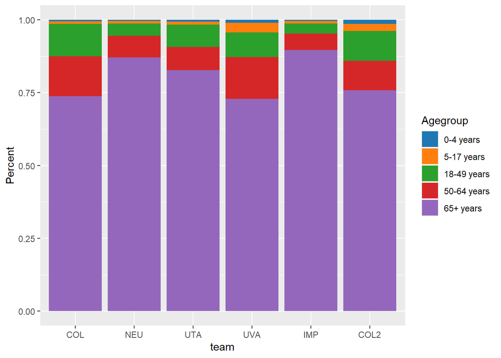

```r
ages <- read_ages(scn = scenario)
ggplot(ages[which(ages$Agegroup != "Overall"),],aes(fill=Agegroup, y=Cml, x=team)) +
  geom_bar(position="fill", stat="identity") +
  ylab("Percent")+
  scale_fill_d3()
```

```r
averted <- rbind(averted, data.frame(scenario = rep(scenario, nrow(table)),
                                     team = table$Team,
                                     reduction = table$`% Reduction in Burden (HP01)`))
averted_age <- rbind(averted_age,
                     data.frame(scenario = scenario,
                          team = ages$team[which(ages$Bin == "sm.mean")],
                          agegroup = ages$Agegroup[which(ages$Bin == "sm.mean")],
                          reduction = 100*(ages_1$Cml[which(ages_1$Bin == "sm.mean")] -
                                       ages$Cml[which(ages$Bin == "sm.mean")]) /
                            ages_1$Cml[which(ages_1$Bin == "sm.mean")]))
```

### HP09

VX1 & SC1 & AV

- “Early”: Vaccine available 100 days after September 1
- Weekly Symptomatic Prevalence > 1% trigger, early (VX1) vaccine availability reopening
- Antivirals

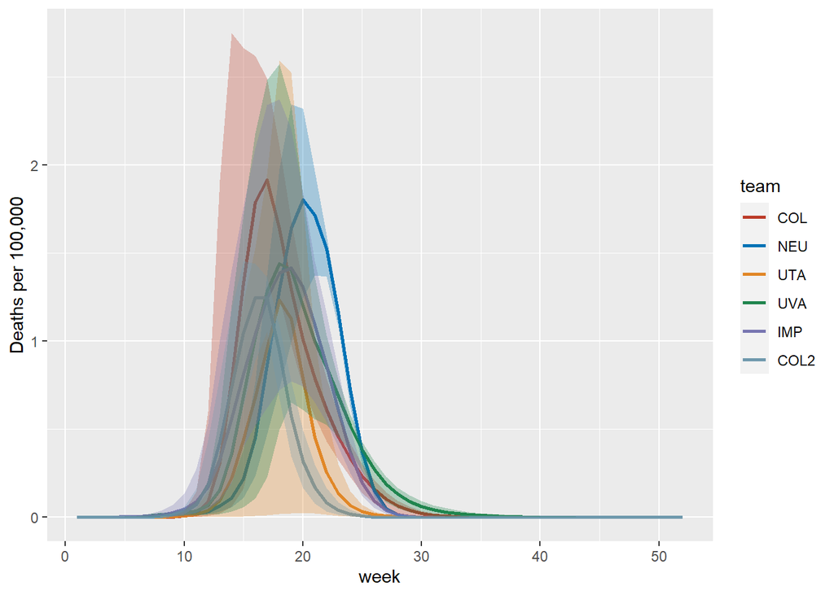

```r
scenario <- "HP09_"

long <- read_overall_mean(scn = scenario)

ggplot(data = long, aes(x = week, y = sm.mean, group = team)) +
  geom_line(aes(color = team), lwd = 1.0) +
  geom_ribbon(aes(ymin = sm.perc2p5, ymax = sm.perc97p5, fill = team), alpha = 0.3,
              show.legend = FALSE)+
  ylab("Deaths per 100,000") +
  scale_color_nejm() +
  scale_fill_nejm()
```

```r
table <- cml[which(cml$Bin == "sm.mean"),]
table <- table[,-3]

table$lower <-  cml$Cml[which(cml$Bin == "sm.perc2p5")]
table$upper <-  cml$Cml[which(cml$Bin == "sm.perc97p5")]
table$Team <- table$team
table$`Cum. Deaths per 100K` <- table$Cml
table$`95% CI` <- paste0("(", round(table$lower, 2), ", ", round(table$upper, 2), ")")

table$`Averted Deaths per 100K (HP01)` <- ifelse(table$Team %in% table1$Team, table1$`Cum. Deaths per 100K` - table$`Cum. Deaths per 100K`, NA)
table$`% Reduction in Burden (HP01)` <- ifelse(table$Team %in% table1$Team, 100 * (table1$`Cum. Deaths per 100K` - table$`Cum. Deaths per 100K`) / table1$`Cum. Deaths per 100K`, NA)

rownames(table) <- NULL

knitr::kable(table[5:9], digits = 2, caption = "HP09: Compared to HP01", align=rep('c', 4)) %>%
  kable_styling(bootstrap_options = c("striped", "hover"))
```

HP09: Compared to HP01

| Team | Cum. Deaths per 100K | 95% CI | Averted Deaths per 100K (HP01) | % Reduction in Burden (HP01) |
| --- | --- | --- | --- | --- |
| COL | 13.02 | (7.58, 20.34) | 7.27 | 35.81 |
| NEU | 12.26 | (11.22, 15.33) | 30.30 | 71.20 |
| UTA | 6.59 | (0.15, 15) | 36.98 | 84.87 |
| UVA | 12.08 | (5.5, 19.4) | 15.48 | 56.16 |
| IMP | 11.75 | (6.57, 18.91) | 24.53 | 67.62 |
| COL2 | 7.18 | (6.18, 8.04) | 13.60 | 65.44 |

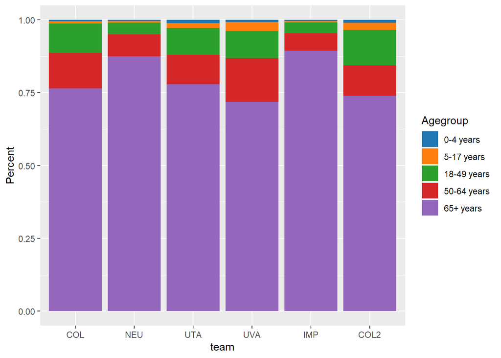

```r
ages <- read_ages(scn = scenario)
ggplot(ages[which(ages$Agegroup != "Overall"),],aes(fill=Agegroup, y=Cml, x=team)) +
  geom_bar(position="fill", stat="identity") +
  ylab("Percent")+
  scale_fill_d3()
```

```r
averted <- rbind(averted, data.frame(scenario = rep(scenario, nrow(table)),
                                     team = table$Team,
                                     reduction = table$`% Reduction in Burden (HP01)`))
averted_age <- rbind(averted_age,
                     data.frame(scenario = scenario,
                          team = ages$team[which(ages$Bin == "sm.mean")],
                          agegroup = ages$Agegroup[which(ages$Bin == "sm.mean")],
                          reduction = 100*(ages_1$Cml[which(ages_1$Bin == "sm.mean")] -
                                       ages$Cml[which(ages$Bin == "sm.mean")]) /
                            ages_1$Cml[which(ages_1$Bin == "sm.mean")]))
```

### HP10

VX1 & SC2 & AV

- “Early”: Vaccine available 100 days after September 1
- Close on October 28, early (VX1) vaccine availability reopening
- Antivirals

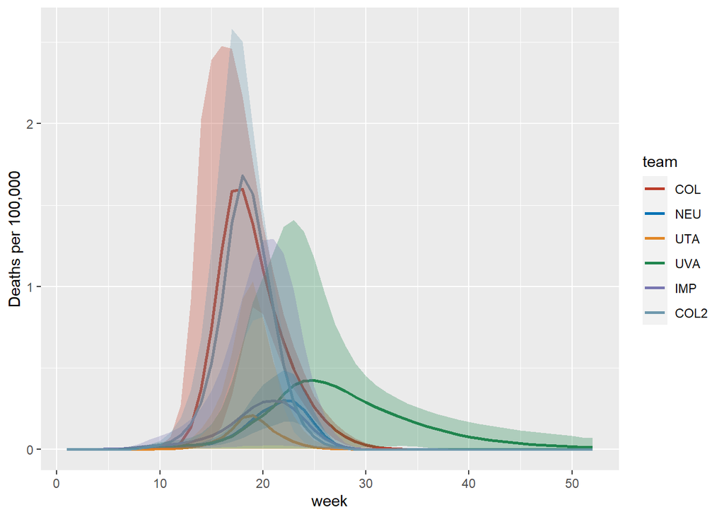

```r
scenario <- "HP10_"

long <- read_overall_mean(scn = scenario)

ggplot(data = long, aes(x = week, y = sm.mean, group = team)) +
  geom_line(aes(color = team), lwd = 1.0) +
  geom_ribbon(aes(ymin = sm.perc2p5, ymax = sm.perc97p5, fill = team), alpha = 0.3,
              show.legend = FALSE)+
  ylab("Deaths per 100,000") +
  scale_color_nejm() +
  scale_fill_nejm()
```

```r
table <- cml[which(cml$Bin == "sm.mean"),]
table <- table[,-3]

table$lower <-  cml$Cml[which(cml$Bin == "sm.perc2p5")]
table$upper <-  cml$Cml[which(cml$Bin == "sm.perc97p5")]
table$Team <- table$team
table$`Cum. Deaths per 100K` <- table$Cml
table$`95% CI` <- paste0("(", round(table$lower, 2), ", ", round(table$upper, 2), ")")

table$`Averted Deaths per 100K (HP01)` <- ifelse(table$Team %in% table1$Team, table1$`Cum. Deaths per 100K` - table$`Cum. Deaths per 100K`, NA)
table$`% Reduction in Burden (HP01)` <- ifelse(table$Team %in% table1$Team, 100 * (table1$`Cum. Deaths per 100K` - table$`Cum. Deaths per 100K`) / table1$`Cum. Deaths per 100K`, NA)

rownames(table) <- NULL

knitr::kable(table[5:9], digits = 2, caption = "HP10: Compared to HP01", align=rep('c', 4)) %>%
  kable_styling(bootstrap_options = c("striped", "hover"))
```

HP10: Compared to HP01

| Team | Cum. Deaths per 100K | 95% CI | Averted Deaths per 100K (HP01) | % Reduction in Burden (HP01) |
| --- | --- | --- | --- | --- |
| COL | 11.32 | (5.95, 18.2) | 8.97 | 44.21 |
| NEU | 2.25 | (1.83, 3.57) | 40.31 | 94.71 |
| UTA | 1.18 | (0, 5.58) | 42.39 | 97.29 |
| UVA | 6.45 | (1.24, 13.34) | 21.11 | 76.60 |
| IMP | 2.65 | (0.27, 10.73) | 33.63 | 92.69 |
| COL2 | 9.87 | (5.63, 13.6) | 10.91 | 52.51 |

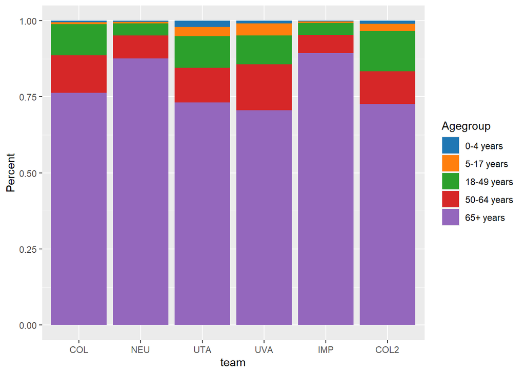

```r
ages <- read_ages(scn = scenario)
ggplot(ages[which(ages$Agegroup != "Overall"),],aes(fill=Agegroup, y=Cml, x=team)) +
  geom_bar(position="fill", stat="identity") +
  ylab("Percent")+
  scale_fill_d3()
```

```r
averted <- rbind(averted, data.frame(scenario = rep(scenario, nrow(table)),
                                     team = table$Team,
                                     reduction = table$`% Reduction in Burden (HP01)`))
averted_age <- rbind(averted_age,
                     data.frame(scenario = scenario,
                          team = ages$team[which(ages$Bin == "sm.mean")],
                          agegroup = ages$Agegroup[which(ages$Bin == "sm.mean")],
                          reduction = 100*(ages_1$Cml[which(ages_1$Bin == "sm.mean")] -
                                       ages$Cml[which(ages$Bin == "sm.mean")]) /
                            ages_1$Cml[which(ages_1$Bin == "sm.mean")]))
```

### HP11

VX2 & SC3 & AV

- “Normal”: Vaccine available 150 days after September 1
- Weekly Symptomatic Prevalence > 1% trigger, normal (VX2) vaccine availability reopening
- Antivirals

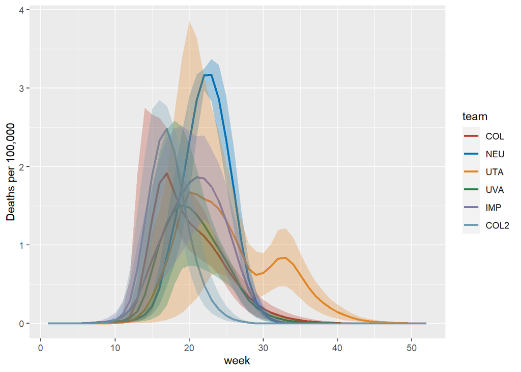

```r
scenario <- "HP11_"

long <- read_overall_mean(scn = scenario)

ggplot(data = long, aes(x = week, y = sm.mean, group = team)) +
  geom_line(aes(color = team), lwd = 1.0) +
  geom_ribbon(aes(ymin = sm.perc2p5, ymax = sm.perc97p5, fill = team), alpha = 0.3,
              show.legend = FALSE)+
  ylab("Deaths per 100,000") +
  scale_color_nejm() +
  scale_fill_nejm()
```

```r
table <- cml[which(cml$Bin == "sm.mean"),]
table <- table[,-3]

table$lower <-  cml$Cml[which(cml$Bin == "sm.perc2p5")]
table$upper <-  cml$Cml[which(cml$Bin == "sm.perc97p5")]
table$Team <- table$team
table$`Cum. Deaths per 100K` <- table$Cml
table$`95% CI` <- paste0("(", round(table$lower, 2), ", ", round(table$upper, 2), ")")

table$`Averted Deaths per 100K (HP01)` <- ifelse(table$Team %in% table1$Team, table1$`Cum. Deaths per 100K` - table$`Cum. Deaths per 100K`, NA)
table$`% Reduction in Burden (HP01)` <- ifelse(table$Team %in% table1$Team, 100 * (table1$`Cum. Deaths per 100K` - table$`Cum. Deaths per 100K`) / table1$`Cum. Deaths per 100K`, NA)

rownames(table) <- NULL

knitr::kable(table[5:9], digits = 2, caption = "HP11: Compared to HP01", align=rep('c', 4)) %>%
  kable_styling(bootstrap_options = c("striped", "hover"))
```

HP11: Compared to HP01

| Team | Cum. Deaths per 100K | 95% CI | Averted Deaths per 100K (HP01) | % Reduction in Burden (HP01) |
| --- | --- | --- | --- | --- |
| COL | 17.83 | (12.48, 24.07) | 2.46 | 12.13 |
| NEU | 25.34 | (25.12, 26.01) | 17.22 | 40.46 |
| UTA | 23.36 | (9.46, 37.64) | 20.21 | 46.38 |
| UVA | 15.65 | (7.53, 23.52) | 11.92 | 43.23 |
| IMP | 20.24 | (14.82, 25.29) | 16.04 | 44.22 |
| COL2 | 16.16 | (14.79, 17.53) | 4.62 | 22.23 |

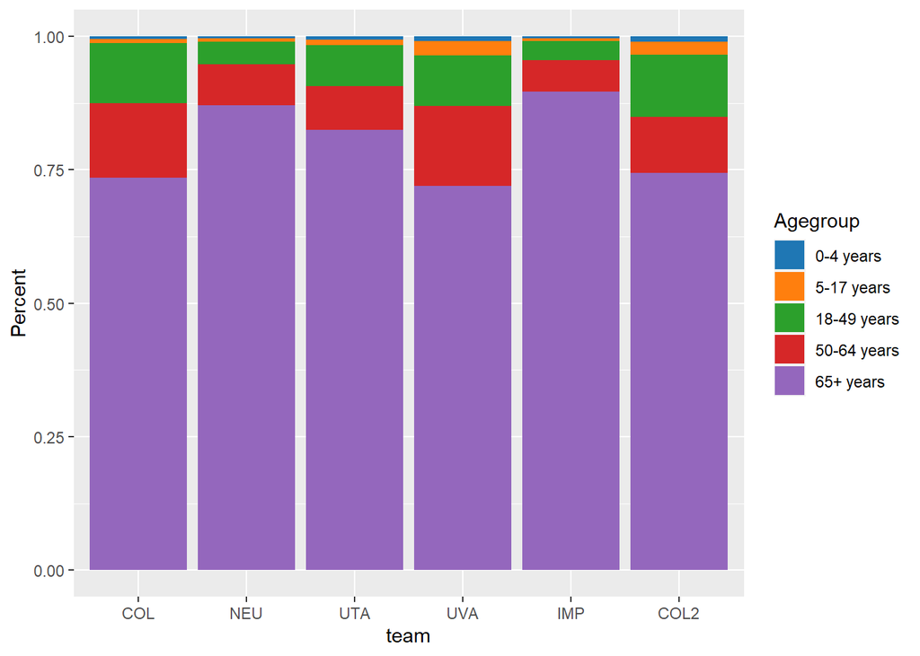

```r
ages <- read_ages(scn = scenario)
ggplot(ages[which(ages$Agegroup != "Overall"),],aes(fill=Agegroup, y=Cml, x=team)) +
  geom_bar(position="fill", stat="identity") +
  ylab("Percent")+
  scale_fill_d3()
```

```r
averted <- rbind(averted, data.frame(scenario = rep(scenario, nrow(table)),
                                     team = table$Team,
                                     reduction = table$`% Reduction in Burden (HP01)`))
averted_age <- rbind(averted_age,
                     data.frame(scenario = scenario,
                          team = ages$team[which(ages$Bin == "sm.mean")],
                          agegroup = ages$Agegroup[which(ages$Bin == "sm.mean")],
                          reduction = 100*(ages_1$Cml[which(ages_1$Bin == "sm.mean")] -
                                       ages$Cml[which(ages$Bin == "sm.mean")]) /
                            ages_1$Cml[which(ages_1$Bin == "sm.mean")]))
```

### HP12

VX2 & SC4 & AV

- “Normal”: Vaccine available 150 days after September 1
- Close on October 28, normal (VX2) vaccine availability reopening
- Antivirals

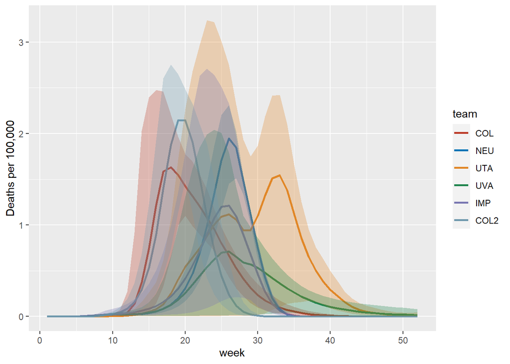

```r
scenario <- "HP12_"

long <- read_overall_mean(scn = scenario)

ggplot(data = long, aes(x = week, y = sm.mean, group = team)) +
  geom_line(aes(color = team), lwd = 1.0) +
  geom_ribbon(aes(ymin = sm.perc2p5, ymax = sm.perc97p5, fill = team), alpha = 0.3,
              show.legend = FALSE)+
  ylab("Deaths per 100,000") +
  scale_color_nejm() +
  scale_fill_nejm()
```

```r
table <- cml[which(cml$Bin == "sm.mean"),]
table <- table[,-3]

table$lower <-  cml$Cml[which(cml$Bin == "sm.perc2p5")]
table$upper <-  cml$Cml[which(cml$Bin == "sm.perc97p5")]
table$Team <- table$team
table$`Cum. Deaths per 100K` <- table$Cml
table$`95% CI` <- paste0("(", round(table$lower, 2), ", ", round(table$upper, 2), ")")

table$`Averted Deaths per 100K (HP01)` <- ifelse(table$Team %in% table1$Team, table1$`Cum. Deaths per 100K` - table$`Cum. Deaths per 100K`, NA)
table$`% Reduction in Burden (HP01)` <- ifelse(table$Team %in% table1$Team, 100 * (table1$`Cum. Deaths per 100K` - table$`Cum. Deaths per 100K`) / table1$`Cum. Deaths per 100K`, NA)

rownames(table) <- NULL

knitr::kable(table[5:9], digits = 2, caption = "HP12: Compared to HP01", align=rep('c', 4)) %>%
  kable_styling(bootstrap_options = c("striped", "hover"))
```

HP12: Compared to HP01

| Team | Cum. Deaths per 100K | 95% CI | Averted Deaths per 100K (HP01) | % Reduction in Burden (HP01) |
| --- | --- | --- | --- | --- |
| COL | 16.88 | (11.62, 23.08) | 3.41 | 16.82 |
| NEU | 13.99 | (12.97, 16.82) | 28.57 | 67.12 |
| UTA | 21.39 | (1.98, 37.9) | 22.18 | 50.91 |
| UVA | 9.76 | (1.33, 20.41) | 17.80 | 64.59 |
| IMP | 10.87 | (1.83, 24.1) | 25.41 | 70.05 |
| COL2 | 15.74 | (13.92, 17.4) | 5.04 | 24.24 |

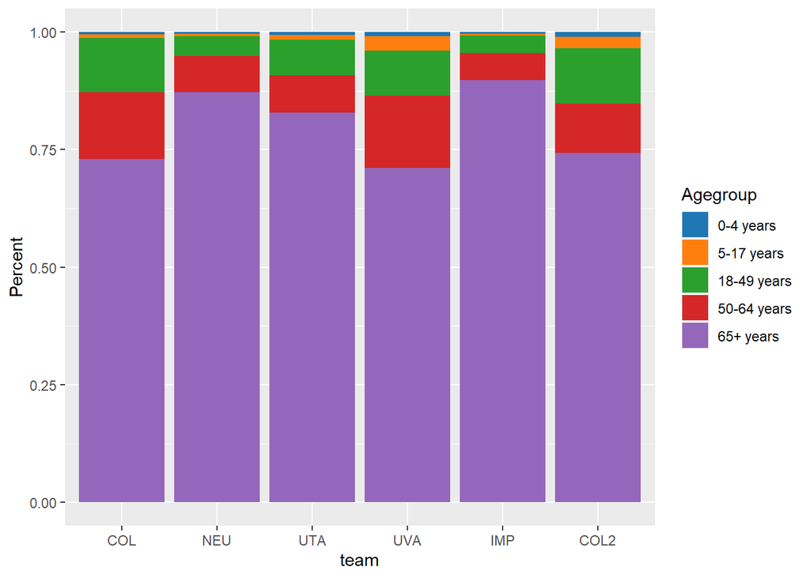

```r
ages <- read_ages(scn = scenario)
ggplot(ages[which(ages$Agegroup != "Overall"),],aes(fill=Agegroup, y=Cml, x=team)) +
  geom_bar(position="fill", stat="identity") +
  ylab("Percent")+
  scale_fill_d3()
```

```r
averted <- rbind(averted, data.frame(scenario = rep(scenario, nrow(table)),
                                     team = table$Team,
                                     reduction = table$`% Reduction in Burden (HP01)`))
averted_age <- rbind(averted_age,
                     data.frame(scenario = scenario,
                          team = ages$team[which(ages$Bin == "sm.mean")],
                          agegroup = ages$Agegroup[which(ages$Bin == "sm.mean")],
                          reduction = 100*(ages_1$Cml[which(ages_1$Bin == "sm.mean")] -
                                       ages$Cml[which(ages$Bin == "sm.mean")]) /
                            ages_1$Cml[which(ages_1$Bin == "sm.mean")]))

write.csv(averted, "Deaths_EPI1.csv")
write.csv(averted_age, "Deaths_age_EPI1.csv")
```